# Homework_problem_2

May Dixon

## 1.

Calculate the population mean and standard deviation for each quantitative random variable (height, weight, age, number of zombies killed, and years of education). NOTE: You will not want to use the built in var() and sd() commands as these are for samples.

```r
attach(R)
mean_z<- function(x) { #generic mean function
      sum(x)/length(x)
}
sd_z<-function(x){ #population standard deviation function
      sqrt(sum((x-mean_z(x))^2)/length(x))
}
```

Means and standard deviations of height, weight, zombies killed, years of education, and age:

```
##   mean_z(height) sd_z(height) mean_z(weight) sd_z(weight)
## 1        67.6301      4.30797       143.9075     18.39186
##   mean_z(zombies_killed) sd_z(zombies_killed) mean_z(years_of_education)
## 1                  2.992             1.747551                      2.996
##   sd_z(years_of_education) mean_z(age) sd_z(age)
## 1                 1.675704    20.04696  2.963583
```

## 2.

Make boxlots with ggplot by gender:

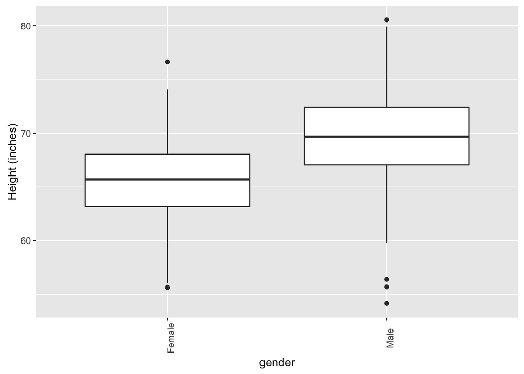

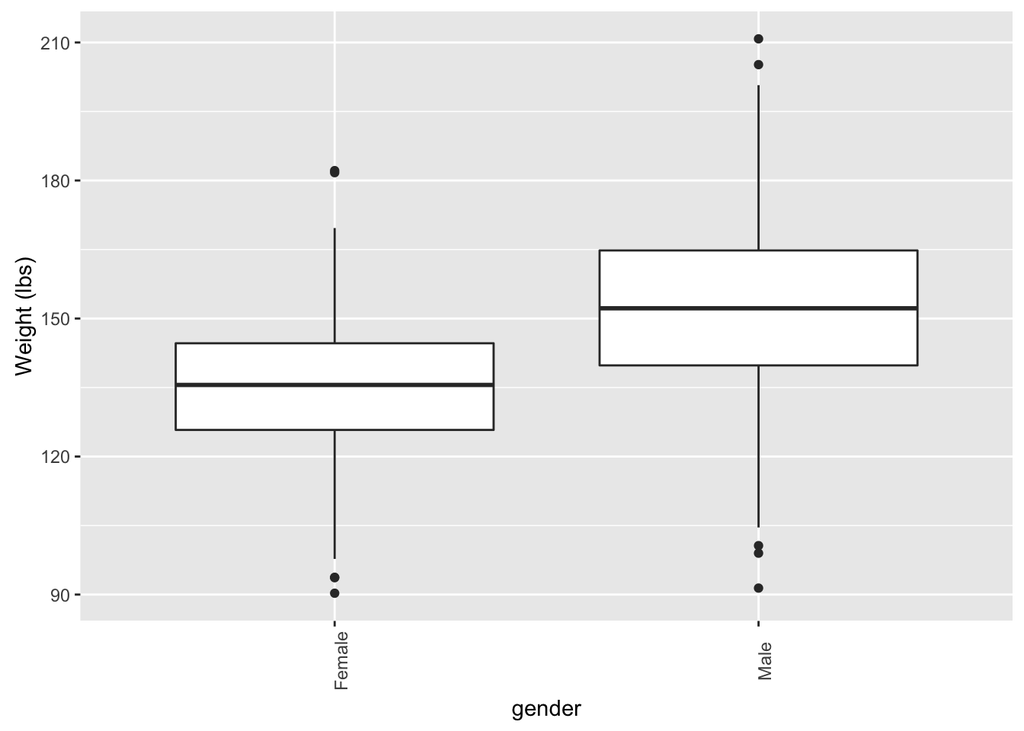

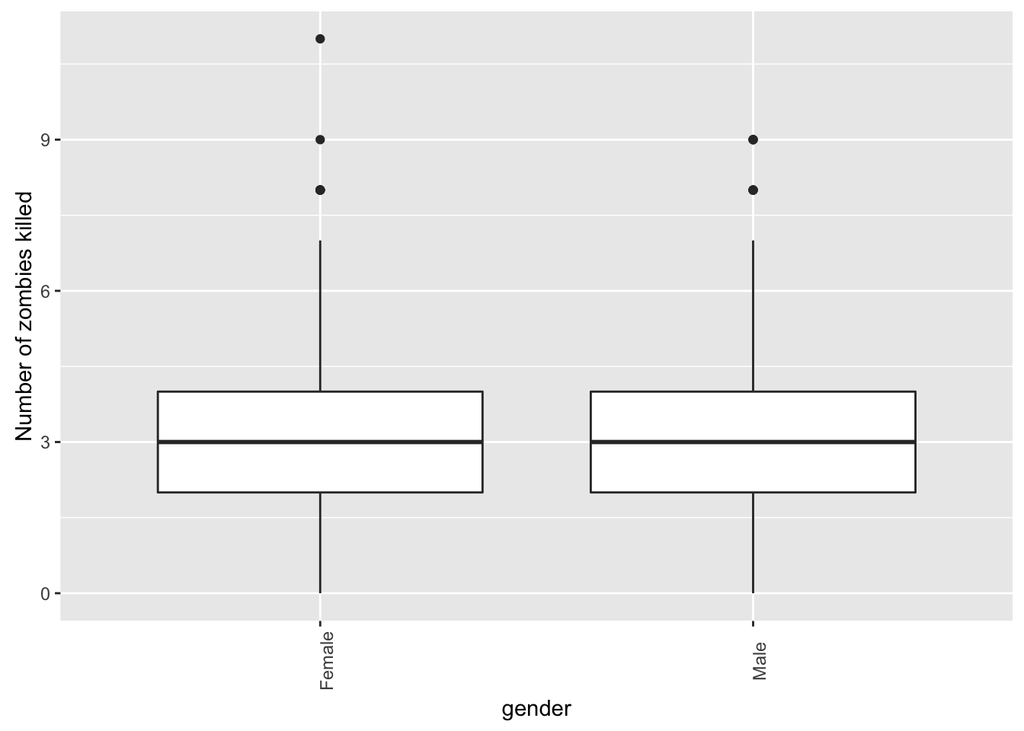

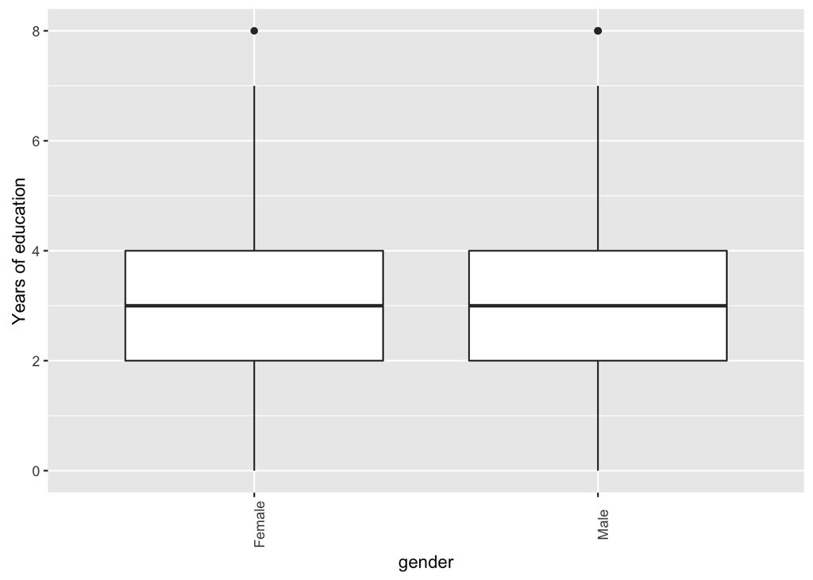

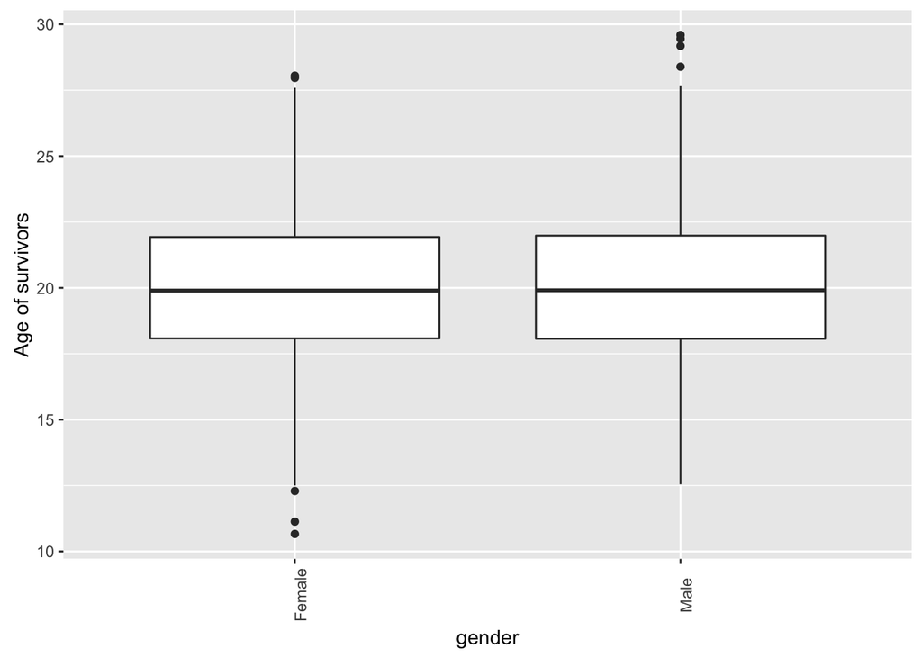

Hooray egalitarian universe!

## 3.

Use ggplot and make a scatterplots of height and weight in relation to age. Do these variables seem to be related? In what way?

[figure not shown]

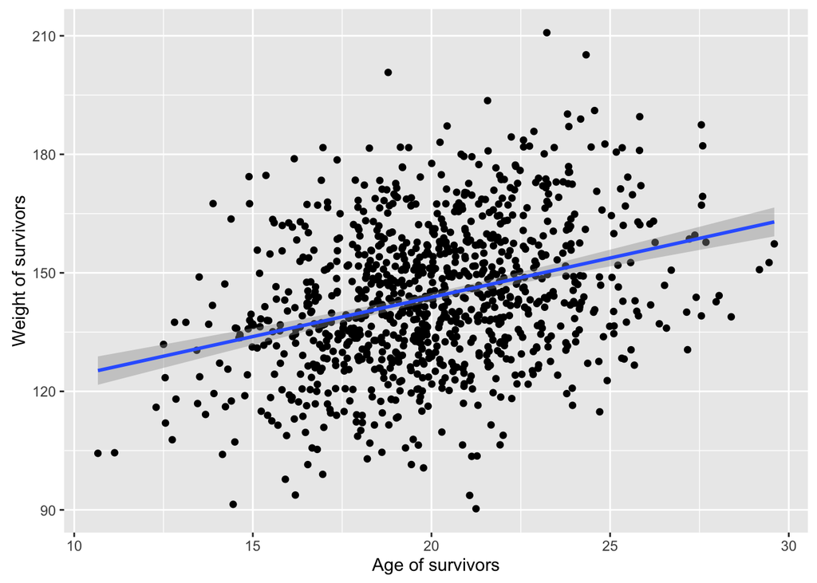

Both height and weight seem to be positively correlated with age, though the correlation seems to be stronger with height than age

## 4.

Using histograms and Q-Q plots, check whether the quantitative variables seem to be drawn from a normal distribution. Which seem to be and which do not (hint: not all are drawn from the normal distribution)? For those that are not, can you determine what common distribution they are drawn from?

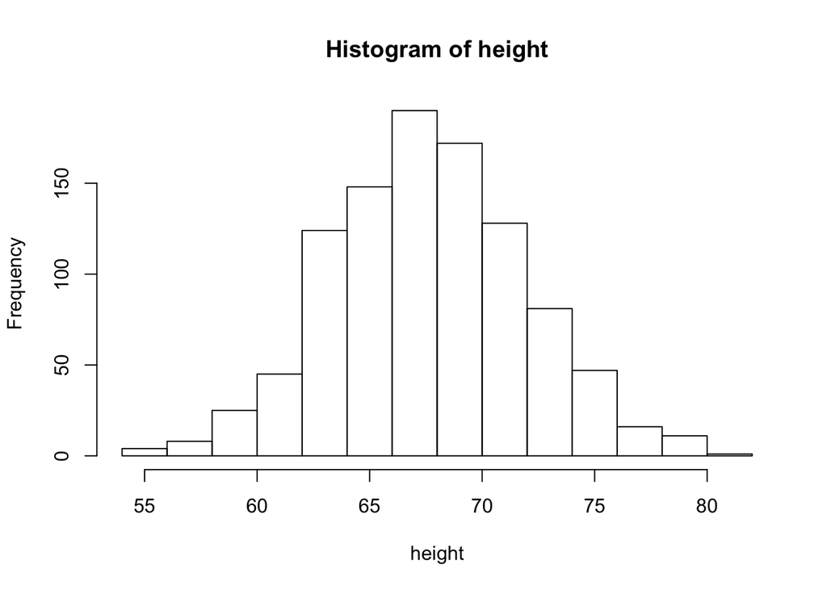

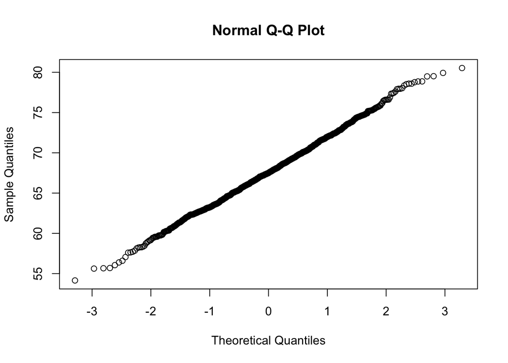

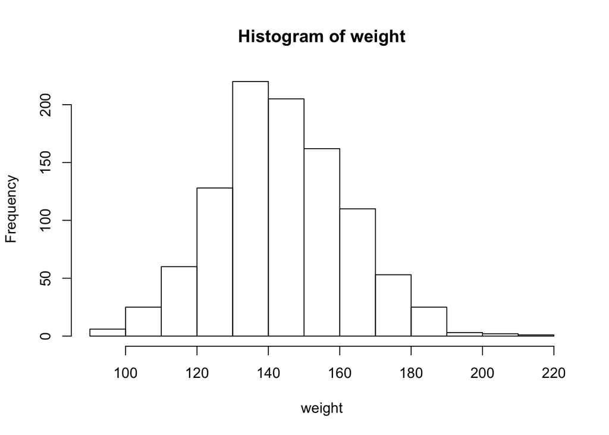

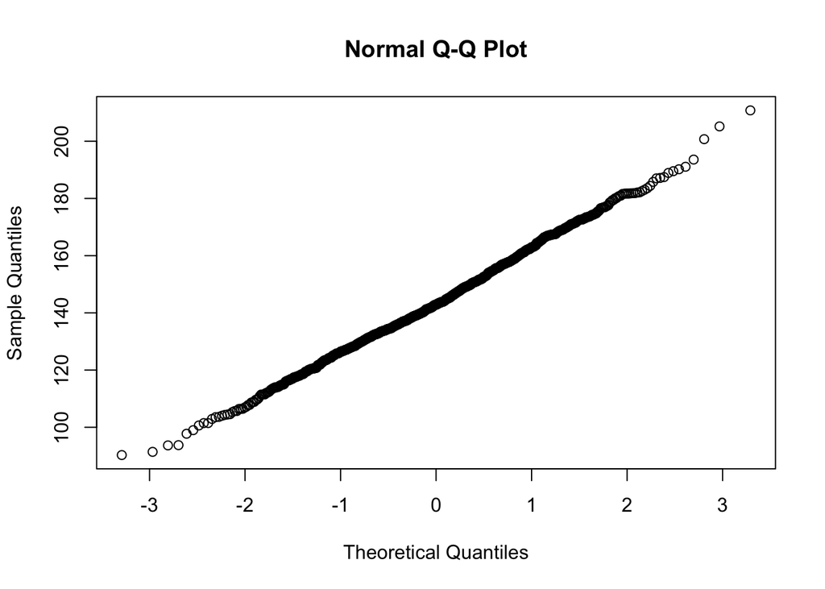

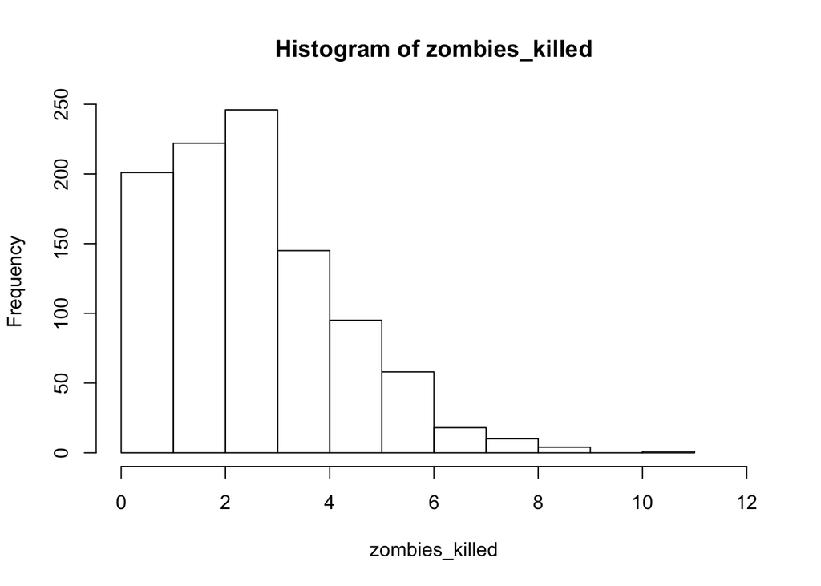

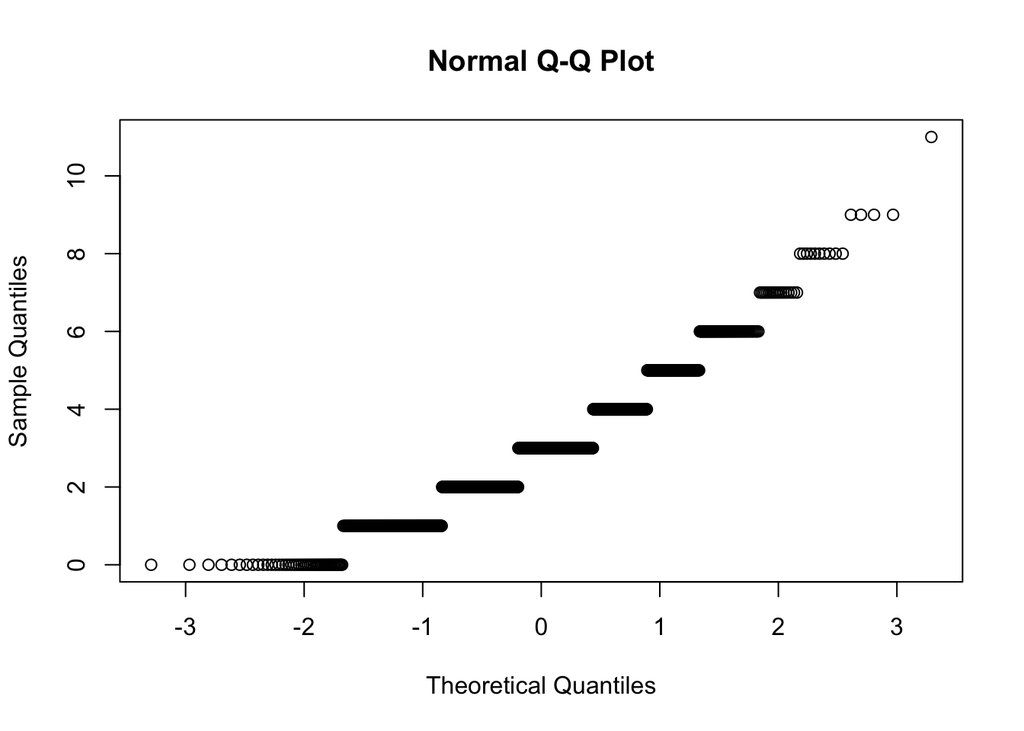

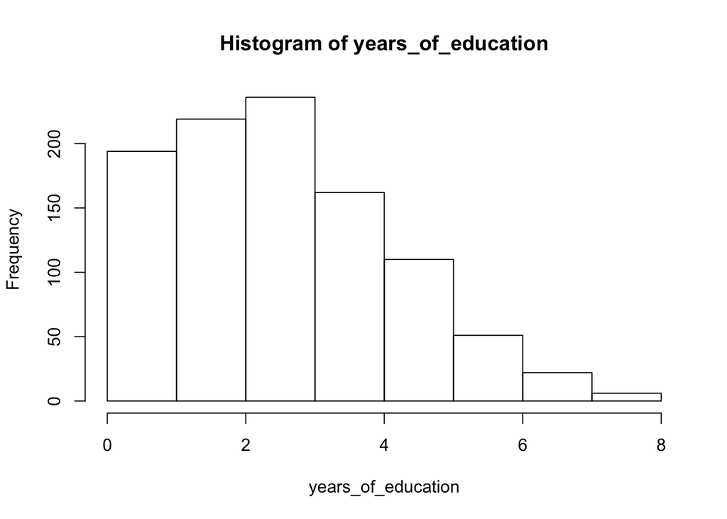

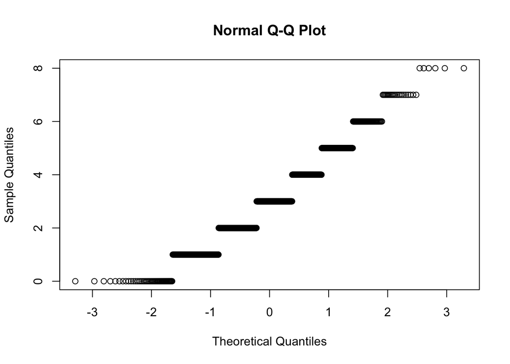

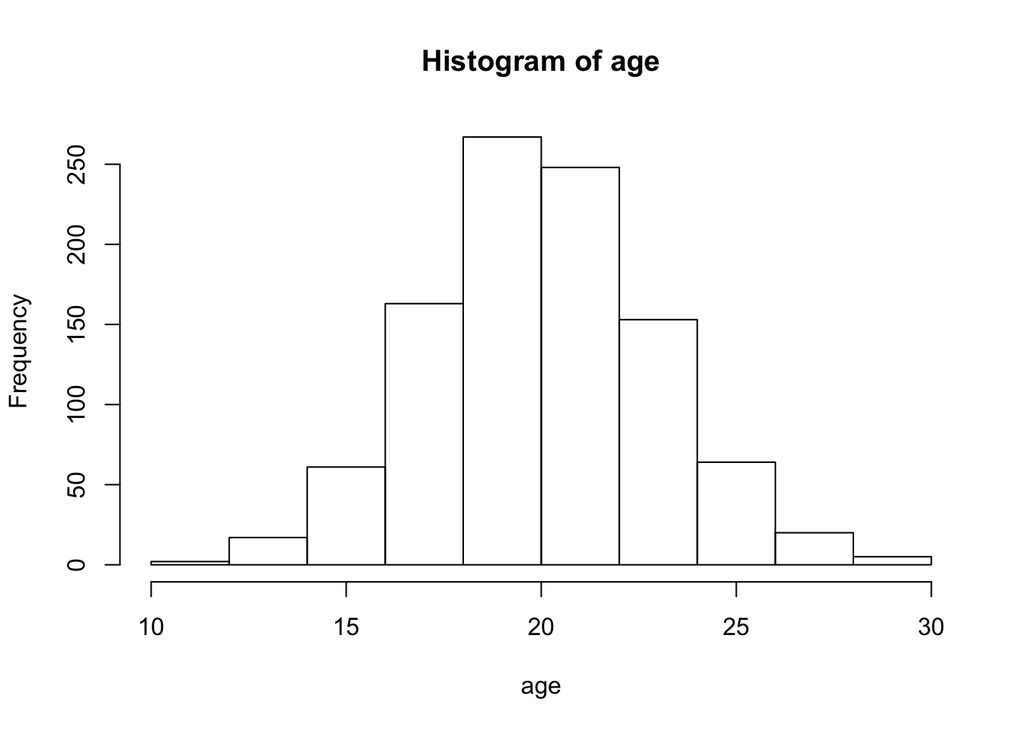

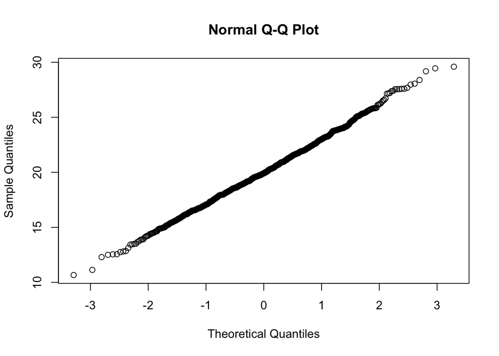

Height, weight, and age seem to be drawn from normal distributions, whereas zombies killed and years of education do not. These variables are both right skewed, and follow **poisson distributions**.

## 5.

Now use the sample() function to sample ONE subset of 30 zombies (without replacement) from this population and calculate the mean and sample standard deviation for each variable. Also estimate the standard error for each variable and construct the 95% confidence interval for each mean. Note that for the variables that are not drawn from the normal distribution, you will need to base your estimate of the CIs on some different distribution.

#### Mean, standard deviation, standard error, and 95% confidence interval for height:

```r
mzs <- mean(height) #mean
sdzs <- sd(height) #standard deviation
sdzs
```

```
## [1] 4.874957
```

```r
sqrt(var(height)) #standard deviation 2
```

```
## [1] 4.874957
```

```r
sqrt(sum((height-mean_z(height))^2)/(length(height)-1)) #standard deviation 3
```

```
## [1] 4.874957
```

```r
#all of these have the same output/ use the same variable, so I'm just going to use the built in one, sqrt
m_pop<-mean(R$height)
m_pop
```

```
## [1] 67.6301
```

```r
se_z<-function(x){ #function for determining standard error of the means, just define m_pop outisde function
    m_sam<-mean(x)
    sqrt(((m_sam - m_pop)^2)/1)

}
se_z(height)
```

```
## [1] 0.8938783
```

```r
#constructing 95% confidence interval
n<-30
error <- qnorm(0.975)*sdzs/sqrt(n)
left <- mzs-error
right <- mzs+error
left
```

```
## [1] 64.99177
```

```r
right
```

```
## [1] 68.48067
```

#### Mean, standard deviation, standard error, and 95% confidence interval for weight:

```r
mzs <- mean(weight) #mean
mzs
```

```
## [1] 142.3427
```

```r
sdzs <- sd(weight) #standard deviation
sdzs
```

```
## [1] 20.40621
```

```r
m_pop<-mean(R$weight)

se_z(weight) #standard error of the mean
```

```
## [1] 1.564732
```

```r
#constructing 95% confidence interval
n<-30
error <- qnorm(0.975)*sdzs/sqrt(n)
left <- mzs-error
right <- mzs+error
left #left tail
```

```
## [1] 135.0406
```

```r
right #right tail
```

```
## [1] 149.6449
```

#### Mean, standard deviation, standard error, and 95% confidence interval for zombies killed:

```r
mzs <- mean(zombies_killed) #mean
mzs
```

```
## [1] 3.033333
```

```r
sdzs <- sd(zombies_killed) #standard deviation
sdzs
```

```
## [1] 2.341284
```

```r
m_pop<-mean(R$zombies_killed)

se_z(zombies_killed) #standard error of the mean
```

```
## [1] 0.04133333
```

```r
#constructing 95% confidence interval
n<-30
lambdaz <- (sum(zombies_killed))/30 #lambda for this dist (total zombies killed/ # people)
error <- qpois(0.975, lambda=lambdaz)*sdzs/sqrt(n)
left <- mzs-error
right <- mzs+error
left #left tail
```

```
## [1] 0.04112762
```

```r
right #right tail
```

```
## [1] 6.025539
```

#### Mean, standard deviation, standard error, and 95% confidence interval for years of education:

```r
mzs <- mean(years_of_education) #mean
mzs
```

```
## [1] 2.866667
```

```r
sdzs <- sd(years_of_education) #standard deviation
sdzs
```

```
## [1] 1.407696
```

```r
m_pop<-mean(R$years_of_education)

se_z(years_of_education) #standard error of the mean
```

```
## [1] 0.1293333
```

```r
#constructing 95% confidence interval
n<-30
lambdaz <- (sum(years_of_education))/30 #lambda for this dist (total years education / # people)
error <- qpois(0.975, lambda=lambdaz)*sdzs/sqrt(n)
left <- mzs-error
right <- mzs+error
left #left tail
```

```
## [1] 1.067603
```

```r
right #right tail
```

```
## [1] 4.66573
```

#### Mean, standard deviation, standard error, and 95% confidence interval for age:

```r
mzs <- mean(age) #mean
mzs
```

```
## [1] 19.3177
```

```r
sdzs <- sd(age) #standard deviation of sample
sdzs
```

```
## [1] 2.729248
```

```r
m_pop<-mean(R$age)

se_z(age) #standard error of the mean
```

```
## [1] 0.7292614
```

```r
#constructing 95% confidence interval
n<-30
error <- qnorm(0.975)*sdzs/sqrt(n)
left <- mzs-error
right <- mzs+error
left #left tail
```

```
## [1] 18.34107
```

```r
right #right tail
```

```
## [1] 20.29433
```

## 6.

Now draw 99 more random samples of 30 zombies out and calculate the mean for each of the these samples. Together with the first sample you drew out, you now have a set of 100 means for each variable (each based on 30 observations), which constitutes a sampling distribution for each variable.

```r
detach(Z_sam)
library(dplyr)
#########
Z_sam_list = list()
mean_heightlist <- NULL
mean_weightlist<- NULL
mean_zombiekilllist<- NULL
mean_educationlist<- NULL
mean_agelist<- NULL

for (i in 1:99) {
    # ... make some data
    z_sam_i <- R[sample(1:1000, 30,replace=FALSE),]
    #Z_sam_list$i <- i  # maybe you want to keep track of which iteration produced it? maybe doesn't matter to save
    #Z_sam_list[[i]] <- z_sam_i # add to list  #again doesn't matter
    mean_heightlist[i]<-mean(z_sam_i$height)
    mean_weightlist[i]<-mean(z_sam_i$weight)
    mean_zombiekilllist[i]<-mean(z_sam_i$zombies_killed)
    mean_educationlist[i]<-mean(z_sam_i$years_of_education)
    mean_agelist[i]<-mean(z_sam_i$age)

}
##########
zombie_means<- cbind(mean_heightlist, mean_weightlist, mean_zombiekilllist,mean_educationlist, mean_agelist)
#add the sample we already have
samp1<- c(69.66241, 151.7363, 2.366667, 2.8, 20.70173)
zombie_means <- rbind(zombie_means, samp1)
```

What are the means and standard deviations of this distribution for each variable? How do the standard deviations compare to the standard errors estimated in [5]? What do these sampling distributions look like? Are they normally distributed? What about for those variables that you concluded were not originally drawn from a normal distribution?

Means and st. devs of distribution of means:

```
##      avgH       sdH     avgW      sdW     avgZ      sdZ     avgE       sdE
## 1 67.5922 0.7329421 144.1077 2.953945 3.001667 0.337761 2.932333 0.2862919
##       avgA      sdA
## 1 19.95911 0.612908
```

Can compare to the summary stats for #5:

```
##       avgH      sdH     avgW      sdW     avgZ      sdZ     avgE      sdE
## 1 66.73622 4.874957 142.3427 20.40621 3.033333 2.341284 2.866667 1.407696
##      avgA      sdA
## 1 19.3177 2.729248
```

And also to the true population means:

```
##      avgH     avgW  avgZ  avgE     avgA
## 1 67.6301 143.9075 2.992 2.996 20.04696
```

^ The bootstrapped means are closer to the population means, and have much smaller standard deviations.

v The distribution of means drawn from other distributions (zombies killed) look normally distributed now.

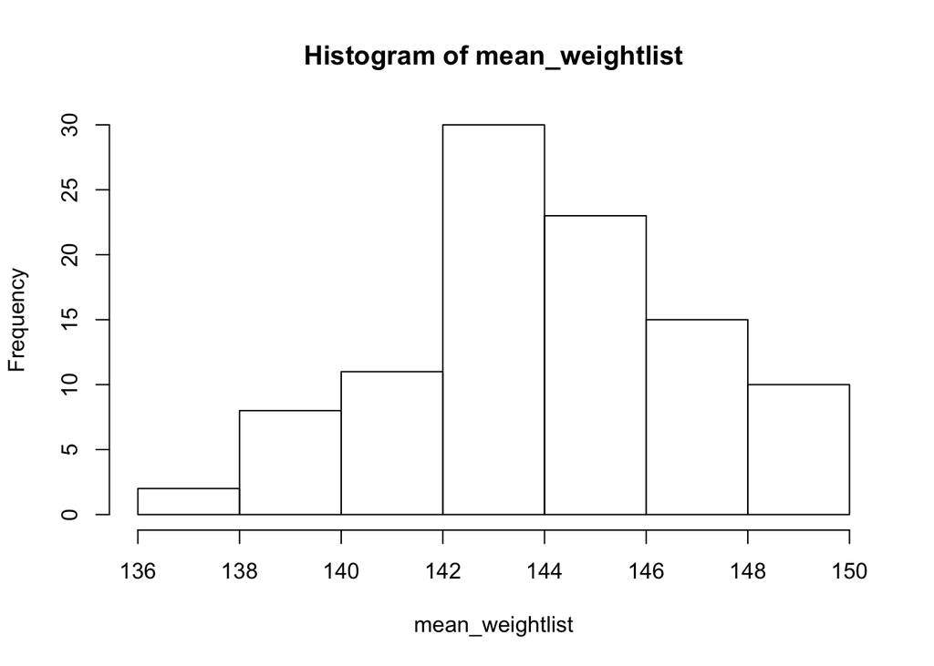

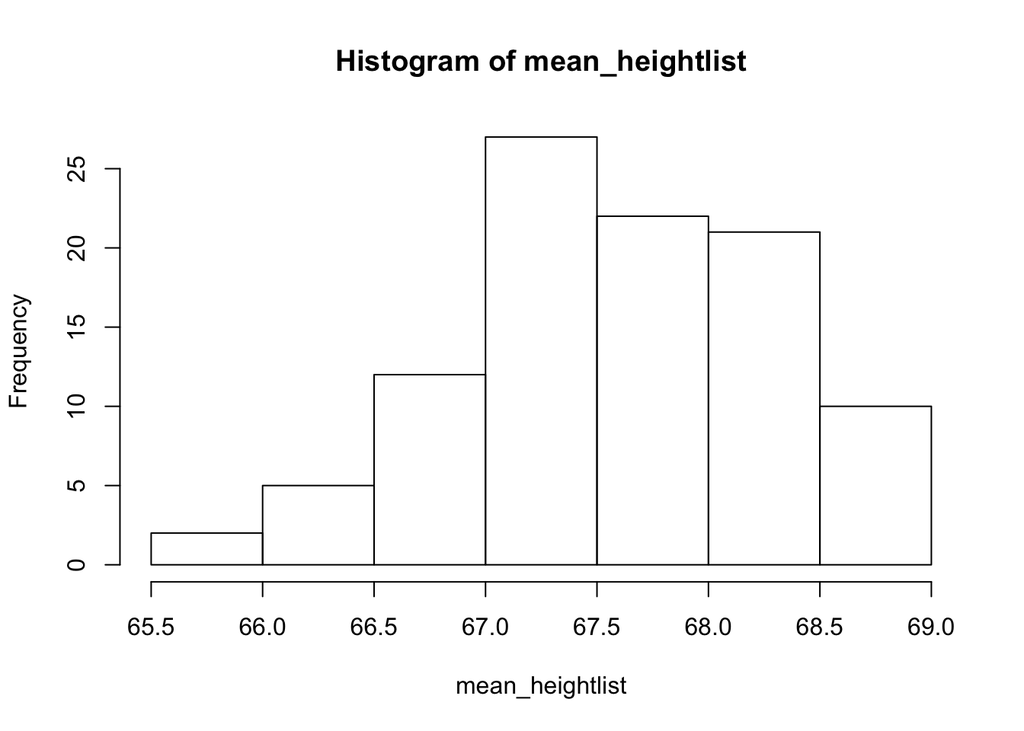

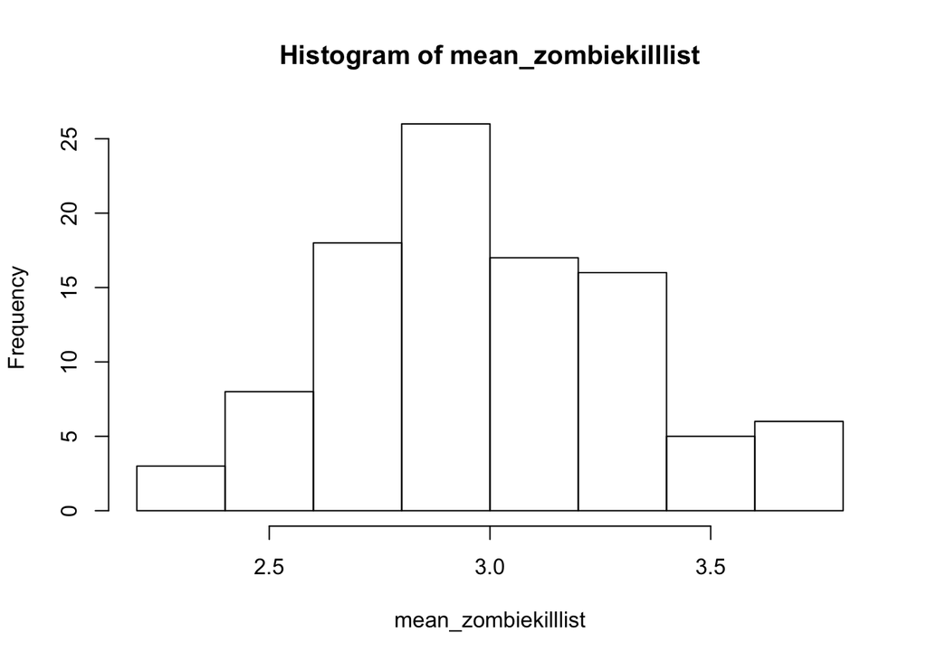

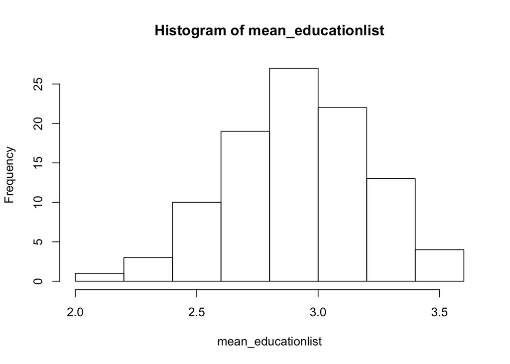

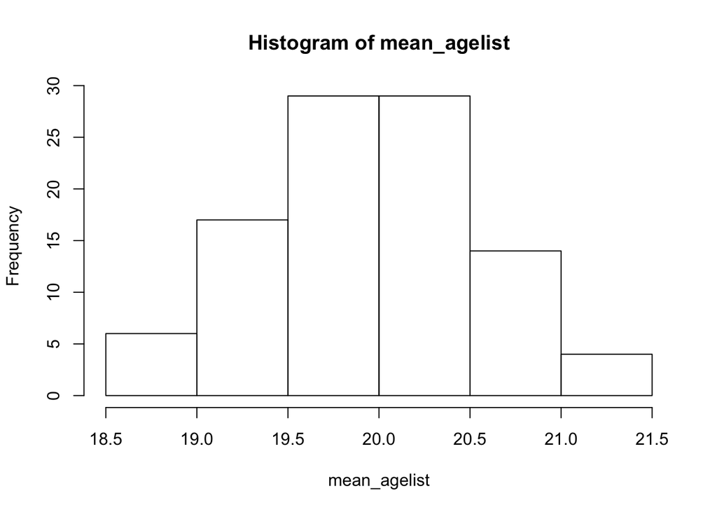